# Non-Parametric ANOVA Problem Set

Your Name Here

# 1 Introduction

This problem set corresponds to the chapter on non-parametric ANOVA in the course https://jacobshermansd.github.io/parametric-trades. The solutions for this problem set use the following packages; however, you may use whatever packages you prefer.

```r
library(tidyverse)
library(dunn.test)
```

# 2 Data Familiarization

For this problem set we will use the `airquality` data set available with base *R*. The data are daily air quality measurements in New York from May to September 1973. We are interested in determining if there are monthly differences in ozone measurements, and if so, which month or months are significantly different than the others. First, familiarize yourself with the data by printing the first few rows and calculating some summary statistics.

```r
head(airquality)
```

```
##   Ozone Solar.R Wind Temp Month Day
## 1    41     190  7.4   67     5   1
## 2    36     118  8.0   72     5   2
## 3    12     149 12.6   74     5   3
## 4    18     313 11.5   62     5   4
## 5    NA      NA 14.3   56     5   5
## 6    28      NA 14.9   66     5   6
```

```r
summary(airquality)
```

```
##      Ozone           Solar.R           Wind             Temp
##  Min.   :  1.00   Min.   :  7.0   Min.   : 1.700   Min.   :56.00
##  1st Qu.: 18.00   1st Qu.:115.8   1st Qu.: 7.400   1st Qu.:72.00
##  Median : 31.50   Median :205.0   Median : 9.700   Median :79.00
##  Mean   : 42.13   Mean   :185.9   Mean   : 9.958   Mean   :77.88
##  3rd Qu.: 63.25   3rd Qu.:258.8   3rd Qu.:11.500   3rd Qu.:85.00
##  Max.   :168.00   Max.   :334.0   Max.   :20.700   Max.   :97.00
##  NA's   :37       NA's   :7
##      Month            Day
##  Min.   :5.000   Min.   : 1.0
##  1st Qu.:6.000   1st Qu.: 8.0
##  Median :7.000   Median :16.0
##  Mean   :6.993   Mean   :15.8
##  3rd Qu.:8.000   3rd Qu.:23.0
##  Max.   :9.000   Max.   :31.0
##
```

## 2.1 Data Transformations

There are missing values in the response (`Ozone`), and the predictor we’re interested in (`Month`) is an integer. Make any changes necessary to prepare for conducting ANOVA.

```r
# Change month from integer to a factor, and remove NAs
aq = airquality %>%
  mutate(Month = as.factor(Month)) %>%
  drop_na(Ozone) %>%
  select(Ozone, Month)
```

## 2.2 Boxplot

Create and display a box plot of the resulting data. Is there visual evidence of a difference in means?

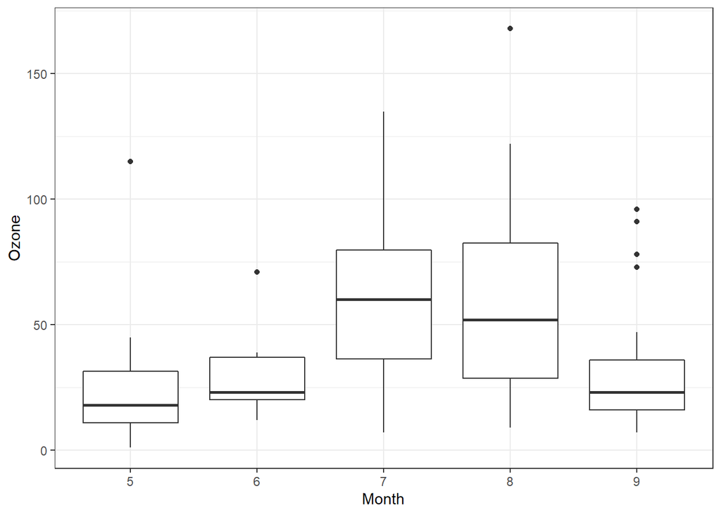

```r
ggplot(aq, aes(x=Month, y=Ozone)) +
  geom_boxplot() +
  theme_bw()
```

```r
# July and August appear to have average ozone reading higher than the other months
```

# 3 Parametric ANOVA

Perform single-factor fixed effects ANOVA and print a summary of the model. Based on the p-value, can we reject the null hypothesis and say that at least one of the effects is non-zero at the 95% confidence level?

```r
aq.aov = aov(Ozone~Month, data=aq)

summary(aq.aov)
```

```
##              Df Sum Sq Mean Sq F value   Pr(>F)
## Month         4  29438    7359   8.536 4.83e-06 ***
## Residuals   111  95705     862
## ---
## Signif. codes:  0 '***' 0.001 '**' 0.01 '*' 0.05 '.' 0.1 ' ' 1
```

```r
# reject the null hypothesis
```

## 3.1 Check Assumptions

Check if the residuals are normally distributed and have constant variance.

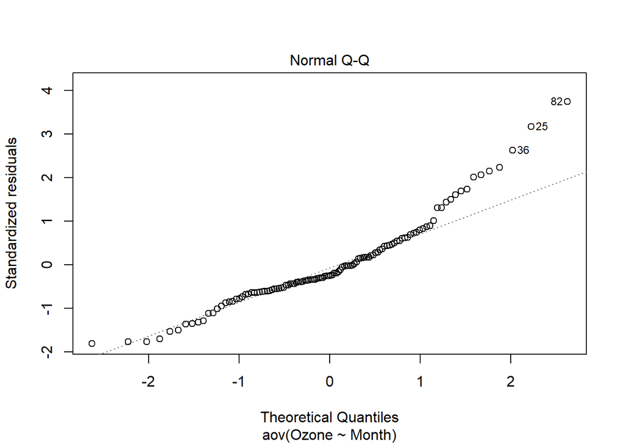

```r
# Q-Q plot
plot(aq.aov, which = 2)
```

```r
# doesn't look promising. Do a shapiro test.
shapiro.test(residuals(aq.aov))
```

```
##
##  Shapiro-Wilk normality test
##
## data:  residuals(aq.aov)
## W = 0.93213, p-value = 1.793e-05
```

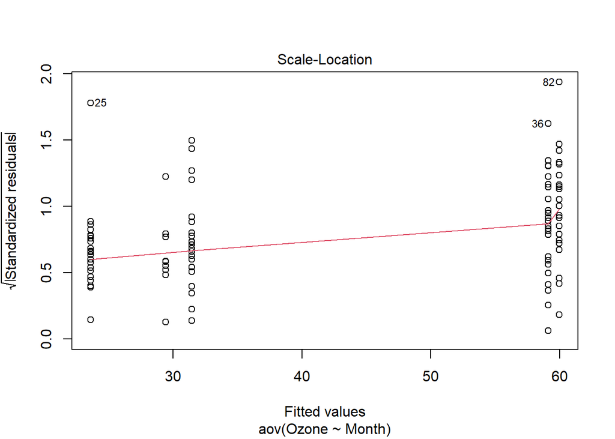

```r
# residuals are not normally distributed

# check for constant variance
plot(aq.aov, which = 3)
```

```r
bartlett.test(Ozone~Month, data=airquality)
```

```
##
##  Bartlett test of homogeneity of variances
##
## data:  Ozone by Month
## Bartlett's K-squared = 13.451, df = 4, p-value = 0.00927
```

```r
# we have non-constance variance
```

# 4 Non-Parametric ANOVA

We didn’t meet the assumptions for parametric ANOVA, so we’ll try non-parametric ANOVA. The only assumption we need to verify is that we have at least 5 observations in each month. Determine if we meet that criteria.

```r
aq %>%
  group_by(Month) %>%
  summarize(count = n())
```

```
## # A tibble: 5 x 2
##   Month count
##   <fct> <int>
## 1 5        26
## 2 6         9
## 3 7        26
## 4 8        26
## 5 9        29
```

```r
# we're good to go
```

## 4.1 Kruskal Wallis Test

Conduct a Kruskal-Wallis test on the data. What does the p-value tell you?

```r
kruskal.test(Ozone ~ Month, data=aq)
```

```
##
##  Kruskal-Wallis rank sum test
##
## data:  Ozone by Month
## Kruskal-Wallis chi-squared = 29.267, df = 4, p-value = 6.901e-06
```

```r
# with the non-parametric test, we reject the null (treatment effect are all =0)
```

## 4.2 Dunn Test

Perform the Dunn test and identify which months differ significantly from the others.

```r
dunn.test(aq$Ozone, aq$Month, kw=FALSE, method="bonferroni")
```

```
##
##                            Comparison of x by group
##                                  (Bonferroni)
## Col Mean-|
## Row Mean |          5          6          7          8
## ---------+--------------------------------------------
##        6 |  -0.925158
##          |     1.0000
##        7 |  -4.419470  -2.244208
##          |    0.0000*     0.1241
##        8 |  -4.132813  -2.038635   0.286657
##          |    0.0002*     0.2074     1.0000
##        9 |  -1.321202   0.002538   3.217199   2.922827
##          |     0.9322     1.0000    0.0065*    0.0173*
##
## alpha = 0.05
## Reject Ho if p <= alpha/2
```

```r
# The following pairs are significant
# 5:7
# 5:8
# 7:9
# 8:9
```